# Final Project Social Media

hp621@scarletmail.rutgers.edu

26/04/2024

#Imported all the necessary Library

```r
library(psych)
library(dplyr)
library(devtools)
```

```r
library(ggplot2)
library(tidyr)
library(FactoMineR)
library(tidyr)
library(MASS)
library(cluster)
library(magrittr)
library(NbClust)
library(factoextra)
library(psych)
library(GGally)
library(car)
library(caret)
library(e1071)
library(pROC)
library(readxl)
library(Hotelling)
library(corrplot)
library(memisc)
library(ROCR)
library(klaR)
library(pROC)
```

#Importing the data The data set was gathered by students from the class. The students had filled the Google form for a month and data was cleaned. The curiosity arise between students and Prof. Ronak Parikh regarding the usage of Social media Furthermore is it good or bad to use social media and What are the major apps running in the market which affects the daily routine of a person.It has 22 observation of 13 variable

```r
social_media <- read_excel("social_media_cleaned.xlsx")
```

Desribe data

```r
dim(social_media)
```

```
## [1] 22 13
```

```r
#It has 22 rows and 13 columns

colnames(social_media)
```

```
##  [1] "character"                    "Instagram"
##  [3] "LinkedIn"                     "SnapChat"
##  [5] "Twitter"                      "Whatsapp"
##  [7] "youtube"                      "OTT"
##  [9] "Reddit"                       "How.you.felt.the.entire.week"
## [11] "Mood.Productivity"            "Tired.waking.up.in.morning"
## [13] "Trouble.falling.asleep"
```

```r
#The name of following columns of the dataset


str(social_media)
```

```
## tibble [22 × 13] (S3: tbl_df/tbl/data.frame)
##  $ character                   : chr [1:22] "masinl" "peace" "Patty" "Bunny" ...
##  $ Instagram                   : num [1:22] 3.5 7.73 3.77 5.38 12 ...
##  $ LinkedIn                    : num [1:22] 4 5.2 7 5.317 0.583 ...
##  $ SnapChat                    : num [1:22] 1 3.683 0.533 1.3 0 ...
##  $ Twitter                     : num [1:22] 5 0 0 0 0.667 ...
##  $ Whatsapp                    : num [1:22] 1 4.18 9.83 5.3 3 ...
##  $ youtube                     : num [1:22] 2.5 4.25 1.85 2 3.5 7 3 2 4 3 ...
##  $ OTT                         : num [1:22] 14.5 0 2 2 2 3 0 3 3 0 ...
##  $ Reddit                      : num [1:22] 2.5 0 0 0 1 0 0 0 0 0 ...
##  $ How.you.felt.the.entire.week: num [1:22] 3 3 4 4 3 5 4 4 3 2 ...
##  $ Mood.Productivity           : num [1:22] 0 1 1 1 1 1 1 1 1 0 ...
##  $ Tired.waking.up.in.morning  : num [1:22] 0 0 0 0 1 0 1 1 0 0 ...
##  $ Trouble.falling.asleep      : num [1:22] 0 1 0 0 1 0 0 1 0 0 ...
```

```r
#It shows the columns character is in character while others are in numeric data


summary(social_media)
```

```
##   character           Instagram          LinkedIn         SnapChat
##  Length:22          Min.   : 0.1667   Min.   : 0.000   Min.   : 0.000
##  Class :character   1st Qu.: 3.9708   1st Qu.: 1.971   1st Qu.: 0.000
##  Mode  :character   Median : 5.5250   Median : 3.833   Median : 0.500
##                     Mean   : 5.9220   Mean   : 3.624   Mean   : 1.884
##                     3rd Qu.: 7.0000   3rd Qu.: 4.750   3rd Qu.: 1.754
##                     Max.   :15.0167   Max.   :10.000   Max.   :14.867
##     Twitter          Whatsapp         youtube           OTT
##  Min.   :0.0000   Min.   : 1.000   Min.   :0.000   Min.   : 0.0000
##  1st Qu.:0.0000   1st Qu.: 3.755   1st Qu.:2.000   1st Qu.: 0.1275
##  Median :0.0000   Median : 6.075   Median :3.000   Median : 1.8000
##  Mean   :0.5538   Mean   : 6.428   Mean   :3.018   Mean   : 2.3989
##  3rd Qu.:0.2000   3rd Qu.: 8.783   3rd Qu.:3.993   3rd Qu.: 2.8667
##  Max.   :5.0000   Max.   :15.350   Max.   :7.000   Max.   :14.5000
##      Reddit       How.you.felt.the.entire.week Mood.Productivity
##  Min.   :0.0000   Min.   :2.000                Min.   :0.0000
##  1st Qu.:0.0000   1st Qu.:3.000                1st Qu.:1.0000
##  Median :0.0000   Median :3.000                Median :1.0000
##  Mean   :0.5005   Mean   :3.409                Mean   :0.9091
##  3rd Qu.:0.0000   3rd Qu.:4.000                3rd Qu.:1.0000
##  Max.   :7.0000   Max.   :5.000                Max.   :1.0000
##  Tired.waking.up.in.morning Trouble.falling.asleep
##  Min.   :0.0000             Min.   :0.0000
##  1st Qu.:0.0000             1st Qu.:0.0000
##  Median :0.0000             Median :0.0000
##  Mean   :0.3636             Mean   :0.3182
##  3rd Qu.:1.0000             3rd Qu.:1.0000
##  Max.   :1.0000             Max.   :1.0000
```

```r
attach(social_media)
```

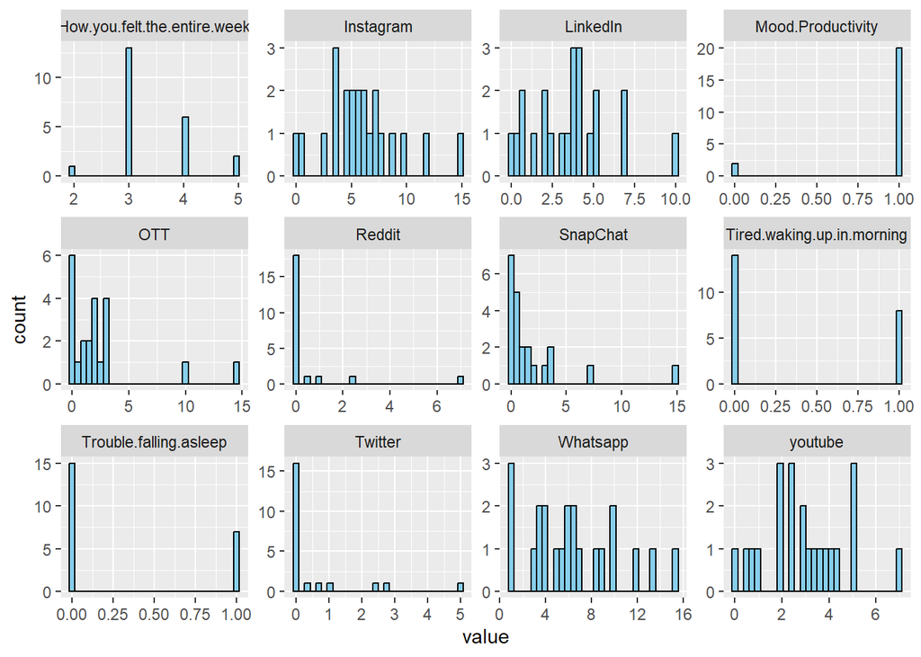

```r
social_media %>%
  dplyr::select(2:13) %>%
  pivot_longer(everything()) %>%
  ggplot(aes(x = value))+
  geom_histogram(bins = 30, color = "black", fill = "skyblue") +
  facet_wrap(~name, scales = "free")
```

#We can identify usage of Instagram, Linkedin, whatsapp, youtube are used highest used #How you felt entire week is factor

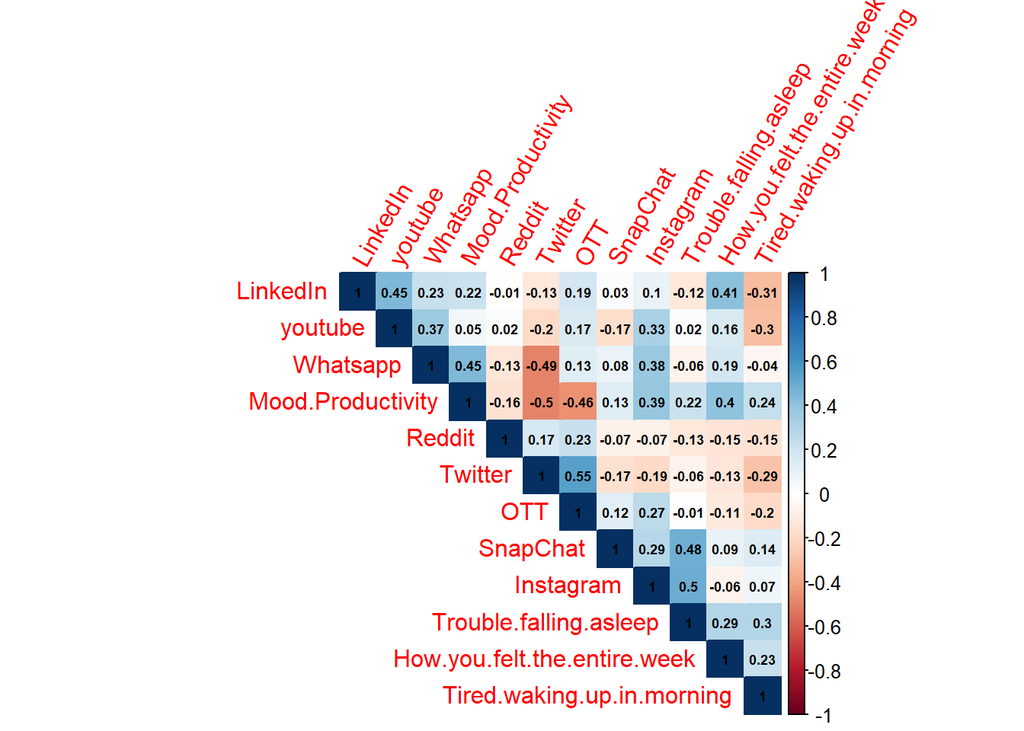

```r
corr_plot_data <- social_media %>%  dplyr::select(How.you.felt.the.entire.week, Instagram, LinkedIn, SnapChat,Twitter,Whatsapp, youtube,Trouble.falling.asleep, Reddit, Tired.waking.up.in.morning, OTT, Mood.Productivity)

corr_matrix <- cor(corr_plot_data)

corrplot(corr_matrix,
         method = "color",
         type = "upper",
         order = "hclust",
         diag = TRUE,
         addCoef.col = TRUE,
         number.cex = 0.55,
         tl.srt = 60)
```

```r
#computing distance between the dataset

scale <- scale(social_media[-1])
#mean of each column
socialmean <- colMeans(social_media[-1])
#correlation of each column
socialcor <- cor(social_media[-1])
#covariance
socialcov <- cov(social_media[-1])



# Computing the Mahalanobis distance for each country
mahalanobis_distance <- function(x) {
  mahalanobis(x, socialmean, socialcov)
}

# Applying the Mahalanobis distance function to each row of the dataset
distance_matrix <- apply(social_media[-1], 1, mahalanobis_distance)

# Converting the distance matrix to a data frame for better readability
distance_df <- data.frame(character , Distance = distance_matrix)

# Displaying the Mahalanobis distance for each column
print(distance_df)
```

```
##    character  Distance
## 1     masinl 18.178932
## 2      peace  8.484319
## 3      Patty  7.720107
## 4      Bunny 11.389252
## 5      tl868  9.860384
## 6      drphy 13.886222
## 7      trave  6.319433
## 8      19!@s  9.086503
## 9     yh2020 14.037988
## 10    ds2134 18.178932
## 11     ki567 11.372645
## 12    ak2001 10.013675
## 13    Harvey 19.016581
## 14     hahah  4.977230
## 15     AKIRA 19.648013
## 16    vp1234  9.653456
## 17     sss32 14.103524
## 18   MVA37@S  5.459765
## 19      2134  4.618906
## 20     15801 15.449143
## 21     Baiqi 11.812430
## 22    aech11  8.732559
```